# slide_deck_template2 slides

## Prosper Loan Data Exploration

### Dataset Overview

There are 113937 rows and 81 columns, most variables data types are in objects, int, float,and bool. from 81 columns, i choosed only 26 columns only,removed duplicated entry from the datasets that makes sure data clean,so of tidy issues are not solved because of data size.

### Investigation Overview

While Investigation of dataset, more focused on CreditGrade , Term , LoanStatus, BorrowerAPR and etc, this investigation more helpful for first time applying loans on prosper and how is loan proposal is selected, so this things decipted in form of charts like hist, scatter, bar charts so on.

## Prosper Loan Status

Current active user of loan prosper are 55730, Completed from prosper loan 38061, Chargedoff from prosper loan11992, Defaulted from prosper loan 5018, Past Due (1-15 days) from prosper loan 800, Past Due (31-60 days) from prosper loan 361, Past Due (61-90 days) from prosper loan 311, Past Due (91-120 days) from prosper loan 304, Past Due (16-30 days) from prosper loan 265, FinalPaymentInProgress from prosper loan 203, Past Due (>120 days) from prosper loan 16, Cancelled from prosper loan 5,

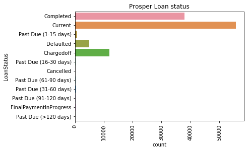

```python
sb.countplot(data = prosper,y='LoanStatus');
plt.xticks(rotation = 90);
plt.title('Prosper Loan status');
```

## Lender Yield Exploration

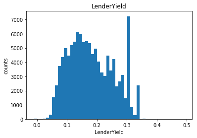

```python
plt.hist(data = prosper,x='LenderYield',bins = 50);
plt.title('LenderYield');
plt.ylabel('counts');
plt.xlabel('LenderYield');
```

## Income verifiable

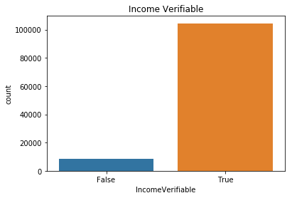

```python
#sb.countplot(df.IncomeVerifiable)

sb.countplot(prosper.IncomeVerifiable);
plt.title('Income Verifiable');
```

## comparing LoanOriginalAmount vs BorrowerRate

LoanOriginalAmount vs Borrowerrate has huge data,intially used scatter plot answer this, but of points are overlapped, so I used hist2d, this chart predict the Borrower Rate of interset with Loan Orginal Amount, for 5000 loan amount most of points lies between 0.2 to 0.35, for 10000 most of points lies between 0.1 to 0.25, for 15000 most of points lies between 0.1 to 0.2, according to this chart when ever loan amount increases Borrower Rate decreases, this may due to small amount of people get large loan amounts.

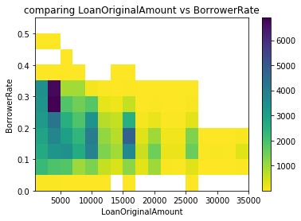

```python
bins_x = np.arange(1000.000000,prosper.LoanOriginalAmount.max() + 100,2000)
bins_y = np.arange(0.000000,prosper.BorrowerRate.max() + 0.1, 0.05)
plt.hist2d(data = prosper,x='LoanOriginalAmount',y='BorrowerRate',cmin=0.5,cmap = 'viridis_r',bins = [bins_x,bins_y]);
plt.title('comparing LoanOriginalAmount vs BorrowerRate');
plt.xlabel('LoanOriginalAmount');
plt.ylabel('BorrowerRate');
plt.colorbar();
plt.show();
```